# Building an Electricity-Planning LP in R

An annotated two-location, two-period example inspired by Schlachtberger et al.

## How to use this notebook

Run the R blocks **in order**, pausing to inspect each object and predict the next result. You can use the Run button on each block in RStudio, or render the whole notebook to see its code, output, formulas, and figures together. The computations are written directly in the blocks; there is no hidden model-building or solution function and no need to source the companion script.

This notebook implements the same model as `Schlachtberger_example.R`. `dplyr`, `tidyr`, and `tibble` organize the inputs and results; base R builds the coefficient matrix; `lpSolve` solves the LP; `ggplot2` illustrates it. When changing an input, rerun the blocks below it so that the matrix and results reflect the new assumptions.

**Scope.** This is a teaching example, not a replication of the full paper. All costs are fictional cost units for the **two-hour horizon**, not annual costs or observed electricity prices. The two hours are consecutive and cyclic. They do not represent a complete day, season, or year.

## 1. Describe the planning problem and enter the data

North (N) can build wind turbines; South (S) can build solar panels. Both can build gas turbines and batteries. A lossless transmission line connects them. Each location needs 4 MW in each of two one-hour periods. Solar is available only in period 1; North’s wind is stronger in period 2.

The planner chooses **installed capacities and hourly operations together** to minimize cost. A carbon budget limits gas generation, and a transmission volume cap limits the connection. Demand, weather, efficiencies, and costs are inputs rather than choices.

### Load packages

Uncomment the installation line only if these packages are missing. The color vector keeps each technology’s color consistent across figures.

```r
# Run once if needed:
# install.packages(c("lpSolve", "dplyr", "tidyr", "tibble", "ggplot2"))
library(lpSolve)
library(dplyr)
library(tidyr)
library(tibble)
library(ggplot2)

theme_set(theme_minimal(base_size = 12))
# Use the same technology colors across figures.
technology_colors <- c(wind = "#397CA8", solar = "#E3AC36", gas = "#777777",
                       battery = "#8865A8", line = "#26998C")
```

### Demand, weather, and policy parameters

Each row of `demand` is one location-hour. Each row of `renewables` supplies the paper’s availability coefficient $\bar g_{n,s,t}$. For example, $\bar g_{N,\mathrm{wind},1}=0.4$: a 5 MW wind installation can produce at most 2 MW in period 1.

The gas emissions coefficient is already $e_s/\eta_s$, in tonnes per MWh of **electricity**. Do not divide it by efficiency again. The one-tonne budget therefore permits at most $1/0.5=2$ MWh of gas generation.

Line length is one normalized distance unit. Thus $lF\le\mathrm{CAP}_{LV}$ is numerically $F\le\mathrm{CAP}_{LV}$ in this example.

```r
# Every row is one location-hour: 4 balances, not one annual balance.
demand <- tribble(
  ~location, ~period, ~demand_MW,
  "N",       1,       4,
  "N",       2,       4,
  "S",       1,       4,
  "S",       2,       4
)

# Availability is the paper's g_bar: output available per MW of capacity.
# These are coefficients, not decision variables.
renewables <- tribble(
  ~location, ~technology, ~period, ~g_bar,
  "N",       "wind",     1,       0.4,
  "N",       "wind",     2,       1.0,
  "S",       "solar",    1,       1.0,
  "S",       "solar",    2,       0.0
)

eta_1 <- 0.9                 # Battery charging efficiency
eta_2 <- 0.9                 # Battery discharging efficiency
h_max <- 1                  # One MWh of energy capacity per MW of battery
line_length <- 1            # One normalized distance unit, NOT an actual km
CAP_LV <- 1                 # Baseline: F * line_length <= 1
CAP_CO2 <- 1                # Tonnes permitted over the two hours
emissions_per_MWh <- 0.5    # e_gas / eta_gas, already per MWh of electricity
# Thus gas can supply at most 2 MWh out of 16 MWh of demand (before losses).
```

### Capacity costs

Capacity costs are charged once over this horizon. Battery cost includes its energy capacity, which is tied to power capacity through $E_{n,\mathrm{battery}}=h_{\max}G_{n,\mathrm{battery}}$ with $h_{\max}=1$ hour. Gas also incurs a dispatch cost, entered in the next section.

```r
# Investment cost per MW for the modeled horizon.
# Battery cost includes its fixed one-hour energy capacity.
capacity_variables <- tribble(
  ~variable,       ~location, ~technology, ~cost,
  "G_N_wind",      "N",       "wind",      2.0,
  "G_S_solar",     "S",       "solar",     1.0,
  "G_N_gas",       "N",       "gas",       0.2,
  "G_S_gas",       "S",       "gas",       0.2,
  "G_N_battery",   "N",       "battery",   0.5,
  "G_S_battery",   "S",       "battery",   0.5,
  "F",            "N-S",     "line",      0.5
)
capacity_variables
```

```
# A tibble: 7 × 4
  variable    location technology  cost
  <chr>       <chr>    <chr>      <dbl>
1 G_N_wind    N        wind         2
2 G_S_solar   S        solar        1
3 G_N_gas     N        gas          0.2
4 G_S_gas     S        gas          0.2
5 G_N_battery N        battery      0.5
6 G_S_battery S        battery      0.5
7 F           N-S      line         0.5
```

### See the availability pattern before solving

The bars show coefficients, **not generation**: installed capacities have not been chosen yet. Predict where a unit of electricity might move in each period. Would a line be useful if both locations had identical production patterns?

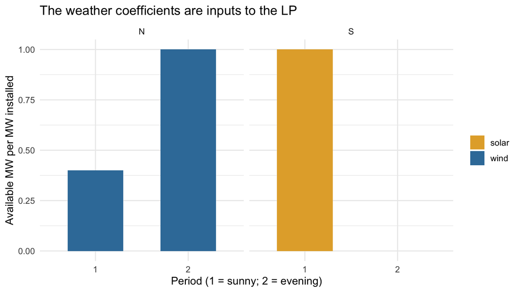

```r
# Plot the exogenous weather inputs before solving anything.
# Prediction: Where might electricity move in each period?
plot_weather <- ggplot(renewables,
                       aes(factor(period), g_bar, fill = technology)) +
  geom_col(width = 0.6) +
  facet_wrap(~location) +
  scale_fill_manual(values = technology_colors) +
  labs(x = "Period (1 = sunny; 2 = evening)",
       y = "Available MW per MW installed", fill = NULL,
       title = "The weather coefficients are inputs to the LP")
print(plot_weather)
```

## 2. Translate the choices into variables and an objective

The notation follows the paper, with explicit labels for technologies and storage operations:

| Mathematical notation | Example R column | Interpretation |
| --- | --- | --- |
| $G_{N,\mathrm{wind}}$ | `G_N_wind` | Installed wind power capacity, MW |
| $g_{N,\mathrm{wind},1}$ | `g_N_wind_1` | Wind dispatch in period 1, MW |
| $G_{S,\mathrm{battery}}$ | `G_S_battery` | Battery power capacity, MW |
| $g_{S,\mathrm{battery},1,\mathrm{charge}}$ | `g_S_charge_1` | Electricity used to charge, MW |
| $g_{S,\mathrm{battery},1,\mathrm{discharge}}$ | `g_S_discharge_1` | Electricity delivered from storage, MW |
| $soc_{S,\mathrm{battery},1}$ | `soc_S_1` | Stored energy after period 1, MWh |
| $F$ | `F` | Capacity of the single line, MW |
| $f_{1}^{NS},f_{1}^{SN}$ | `f_NS_1`, `f_SN_1` | Nonnegative directional flows, MW |

Because there is only one storage technology, the code omits `battery` from its operating variable names. The paper’s net battery dispatch is $g_{n,\mathrm{battery},t}=g_{n,\mathrm{battery},t,\mathrm{discharge}} -g_{n,\mathrm{battery},t,\mathrm{charge}}$.

`lpSolve` assumes nonnegative decision variables. The paper’s signed line flow is represented by $f_t=f_t^{NS}-f_t^{SN}$. These directional variables are an implementation choice, not two separate transmission lines.

### Enumerate each operating decision

`crossing()` enumerates combinations of location, period, and operation. The `capacity` column tells us which investment bounds each generator’s output. Inspect `generation_variables` before moving on.

```r
# Build a table so each matrix column has a name and an economic meaning.
# Each generator needs a dispatch decision in each of the two periods.
gas <- crossing(location = c("N", "S"), period = 1:2) |>
  mutate(technology = "gas", g_bar = 1)

generation_variables <- bind_rows(renewables, gas) |>
  mutate(variable = paste("g", location, technology, period, sep = "_"),
         capacity = paste("G", location, technology, sep = "_"),
         cost = if_else(technology == "gas", 1, 0))

# Charge and discharge are electricity entering/leaving the battery (MW).
# soc is energy INSIDE the battery at the end of each period (MWh).
storage_variables <- crossing(location = c("N", "S"), period = 1:2,
                              operation = c("charge", "discharge", "soc")) |>
  mutate(variable = if_else(operation == "soc",
                            paste("soc", location, period, sep = "_"),
                            paste("g", location, operation, period, sep = "_")),
         cost = 0)

flow_variables <- crossing(direction = c("NS", "SN"), period = 1:2) |>
  mutate(variable = paste("f", direction, period, sep = "_"), cost = 0)
```

### Write the objective before passing it to the solver

The paper’s objective combines capacity and dispatch costs:

$$\min\;\sum_{n,s}c_{n,s}G_{n,s}+c_\ell F
+\sum_{n,s,t}o_{n,s}g_{n,s,t}.$$

For our technology menu and numerical assumptions this becomes

$$\begin{aligned}
\min\quad
&2G_{N,\mathrm{wind}}+G_{S,\mathrm{solar}}
+0.2(G_{N,\mathrm{gas}}+G_{S,\mathrm{gas}})\\
&+0.5(G_{N,\mathrm{battery}}+G_{S,\mathrm{battery}})+0.5F\\
&+\sum_{n\in\{N,S\}}\sum_{t=1}^{2}g_{n,\mathrm{gas},t}.
\end{aligned}$$

Renewable dispatch, storage operation, and flows have zero variable cost in this example. Every hour lasts one hour, so dispatch in MW multiplies one hour to give the MWh used in operating costs.

We stack all 31 decisions into $x$ and put these cost coefficients into $c$. The solver sees $\min c^\top x$. **Column order is part of the formulation**: `variables`, `objective`, the matrix, and the solution must use the same order.

```r
# This column order must be identical in the objective, matrix, and solution.
variables <- bind_rows(
  capacity_variables |> select(variable, cost),
  generation_variables |> select(variable, cost),
  storage_variables |> select(variable, cost),
  flow_variables |> select(variable, cost)
)
print(variables, n = Inf)
```

```
# A tibble: 31 × 2
   variable         cost
   <chr>           <dbl>
 1 G_N_wind          2
 2 G_S_solar         1
 3 G_N_gas           0.2
 4 G_S_gas           0.2
 5 G_N_battery       0.5
 6 G_S_battery       0.5
 7 F                 0.5
 8 g_N_wind_1        0
 9 g_N_wind_2        0
10 g_S_solar_1       0
11 g_S_solar_2       0
12 g_N_gas_1         1
```

[output cut: 19 more lines]

```r
nrow(variables)              # 31 nonnegative decision variables
```

```
[1] 31
```

```r
objective <- setNames(variables$cost, variables$variable)
objective
```

```
       G_N_wind       G_S_solar         G_N_gas         G_S_gas     G_N_battery
            2.0             1.0             0.2             0.2             0.5
    G_S_battery               F      g_N_wind_1      g_N_wind_2     g_S_solar_1
            0.5             0.5             0.0             0.0             0.0
    g_S_solar_2       g_N_gas_1       g_N_gas_2       g_S_gas_1       g_S_gas_2
            0.0             1.0             1.0             1.0             1.0
   g_N_charge_1 g_N_discharge_1         soc_N_1    g_N_charge_2 g_N_discharge_2
            0.0             0.0             0.0             0.0             0.0
        soc_N_2    g_S_charge_1 g_S_discharge_1         soc_S_1    g_S_charge_2
            0.0             0.0             0.0             0.0             0.0
g_S_discharge_2         soc_S_2          f_NS_1          f_NS_2          f_SN_1
            0.0             0.0             0.0             0.0             0.0
         f_SN_2
            0.0
```

```r
# Capacity costs appear once. Dispatch cost appears for each hour.
# Each period lasts one hour, so MW * 1 hour = MWh in operating costs.
```

## 3. Translate physical and policy restrictions into matrix rows

Each row of $A$ is a restriction; each column is one decision in $x$. The vector `constraint_direction` says whether a row is an equality or an upper bound. `rhs` contains demand levels, policy caps, or zero after terms have been moved to the left-hand side.

### Start with an empty matrix

We create 34 named rows, initialize their coefficients to zero, and fill them by economic meaning. Repeated operations use visible loops. No solver is called until the entire LP has been assembled.

```r
# Rows = constraints. Columns = decisions. Start with zeros, then fill entries.
# Loops below repeat transparent row-writing steps; they do not hide a solve.
balance_rows <- paste("balance", demand$location, demand$period, sep = "_")
generation_rows <- paste0("limit_", generation_variables$variable)
storage_rows <- paste0("limit_", storage_variables$variable)
stock_rows <- paste("stock", rep(c("N", "S"), each = 2), rep(1:2, 2), sep = "_")
flow_rows <- paste0("limit_", flow_variables$variable)
row_names <- c(balance_rows, generation_rows, storage_rows, stock_rows,
               flow_rows, "line_volume", "carbon")

A <- matrix(0, nrow = length(row_names), ncol = nrow(variables),
            dimnames = list(row_names, variables$variable))
constraint_direction <- setNames(rep("<=", nrow(A)), row_names)
rhs <- setNames(rep(0, nrow(A)), row_names)
```

### Electricity balances: four equalities

The paper writes $\sum_s g_{n,s,t}-d_{n,t}=\sum_\ell K_{n\ell}f_{\ell,t}$, where storage contributes its signed net dispatch. Expanding the terms in our model gives, for each $t=1,2$,

$$\begin{aligned}
g_{N,\mathrm{wind},t}+g_{N,\mathrm{gas},t}
+g_{N,\mathrm{battery},t,\mathrm{discharge}}
-g_{N,\mathrm{battery},t,\mathrm{charge}}-f_t^{NS}+f_t^{SN}&=4,\\
g_{S,\mathrm{solar},t}+g_{S,\mathrm{gas},t}
+g_{S,\mathrm{battery},t,\mathrm{discharge}}
-g_{S,\mathrm{battery},t,\mathrm{charge}}+f_t^{NS}-f_t^{SN}&=4.
\end{aligned}$$

Imports have a positive sign, exports a negative sign. Charging consumes local electricity. When we add the two countries’ balances, trade cancels. An annual or horizon-wide balance alone would not ensure either hour works.

The four rows below are written explicitly. The printed matrix shows a selected set of columns so that the flow signs remain easy to inspect.

```r
# 3a. Supply + discharge - charge + imports - exports = demand.
# Write all FOUR balances explicitly so students can check the flow signs.
A["balance_N_1", c("g_N_wind_1", "g_N_gas_1", "g_N_discharge_1",
                    "g_N_charge_1", "f_NS_1", "f_SN_1")] <- c(1, 1, 1, -1, -1, 1)
A["balance_N_2", c("g_N_wind_2", "g_N_gas_2", "g_N_discharge_2",
                    "g_N_charge_2", "f_NS_2", "f_SN_2")] <- c(1, 1, 1, -1, -1, 1)
A["balance_S_1", c("g_S_solar_1", "g_S_gas_1", "g_S_discharge_1",
                    "g_S_charge_1", "f_NS_1", "f_SN_1")] <- c(1, 1, 1, -1, 1, -1)
A["balance_S_2", c("g_S_solar_2", "g_S_gas_2", "g_S_discharge_2",
                    "g_S_charge_2", "f_NS_2", "f_SN_2")] <- c(1, 1, 1, -1, 1, -1)
constraint_direction[balance_rows] <- "="
rhs[balance_rows] <- demand$demand_MW
A[balance_rows, c("g_N_wind_1", "g_N_gas_1", "f_NS_1", "f_SN_1")]
```

```
            g_N_wind_1 g_N_gas_1 f_NS_1 f_SN_1
balance_N_1          1         1     -1      1
balance_N_2          0         0      0      0
balance_S_1          0         0      1     -1
balance_S_2          0         0      0      0
```

### Generator limits: dispatch requires available capacity

For generation technologies,

$$0\le g_{n,s,t}\le\bar g_{n,s,t}G_{n,s}
\quad\Longleftrightarrow\quad
g_{n,s,t}-\bar g_{n,s,t}G_{n,s}\le0.$$

The nonnegative lower bound is supplied by `lpSolve`. The matrix row contains $1$ on output and $-\bar g$ on installed capacity. Weather is a fixed coefficient, so this is linear. Gas uses $\bar g=1$.

**What does 0.4 mean?** It encodes the assumed less favorable wind conditions in period 1: output can reach at most 40% of installed capacity. Period 2’s coefficient of 1.0 represents conditions permitting 100% of installed capacity. These weather assumptions are fixed inputs, not decisions made by the optimizer.

Both periods use the same installed-capacity variable:

$$\begin{aligned}
g_{N,\mathrm{wind},1}-0.4G_{N,\mathrm{wind}}&\le0,\\
g_{N,\mathrm{wind},2}-1.0G_{N,\mathrm{wind}}&\le0.
\end{aligned}$$

With 5 MW installed, output is limited to **2 MW in period 1** and **5 MW in period 2**. The negative coefficients result from moving available capacity to the left: $g\le0.4G$ becomes $g-0.4G\le0$. Thus each matrix row has $+1$ on hourly output, minus availability on installed capacity, and zero on unrelated decisions; its right-hand side is zero.

**Full availability permits full generation; it does not require it.** Actual output can be lower if electricity is not needed, stored, or exported. For South’s period-2 solar, it is simply $g_{S,\mathrm{solar},2}\le0$. The inequality allows curtailment; no siting upper bounds on $G$ are imposed here.

```r
# 3b. Generator output <= g_bar * G. Rearrange as g - g_bar * G <= 0.
for (i in seq_len(nrow(generation_variables))) {
  row <- generation_rows[i]
  A[row, generation_variables$variable[i]] <- 1
  A[row, generation_variables$capacity[i]] <- -generation_variables$g_bar[i]
}
A["limit_g_N_wind_1", A["limit_g_N_wind_1", ] != 0]       # g_N_wind_1 - 0.4 G_N_wind <= 0
```

```
  G_N_wind g_N_wind_1
      -0.4        1.0
```

```r
A["limit_g_S_solar_2", A["limit_g_S_solar_2", ] != 0]      # No sunlight: g_S_solar_2 <= 0
```

```
[1] 1
```

```r
# No upper siting limits are imposed on installed generation in this toy model.
```

### Battery limits: distinguish power from energy

For each location and period,

$$\begin{aligned}
0\le g_{n,\mathrm{battery},t,\mathrm{charge}}&\le G_{n,\mathrm{battery}},\\
0\le g_{n,\mathrm{battery},t,\mathrm{discharge}}&\le G_{n,\mathrm{battery}},\\
0\le soc_{n,\mathrm{battery},t}&\le h_{\max}G_{n,\mathrm{battery}}.
\end{aligned}$$

The first two rows limit charging and discharging power. The third limits stored energy. With $h_{\max}=1$, their right-hand-side coefficients happen to match numerically, but their physical units and roles differ.

```r
# 3c. Battery charge/discharge <= G_battery; soc <= h_max * G_battery.
for (i in seq_len(nrow(storage_variables))) {
  row <- storage_rows[i]
  capacity <- paste("G", storage_variables$location[i], "battery", sep = "_")
  A[row, storage_variables$variable[i]] <- 1
  A[row, capacity] <- if (storage_variables$operation[i] == "soc") -h_max else -1
}
```

### Storage accounting: connect the two periods

With no natural inflow or spillage for our batteries, the paper’s storage balance is

$$soc_{n,\mathrm{battery},t}=soc_{n,\mathrm{battery},t-1}
+\eta_1g_{n,\mathrm{battery},t,\mathrm{charge}}
-\eta_2^{-1}g_{n,\mathrm{battery},t,\mathrm{discharge}}.$$

The power terms implicitly multiply one hour. Rearranging gives coefficients $+1,-1,-\eta_1,+1/\eta_2$ on current stock, previous stock, charge, and discharge.

We impose $soc_{n,\mathrm{battery},0}=soc_{n,\mathrm{battery},2}$ by using period 2 as period 1’s previous stock. This eliminates a separate initial stock variable; it does **not** impose an initial stock of zero. The horizon is a repeating two-hour cycle, so any energy drawn from its initial stock must be replenished by the end.

**Check the efficiency:** storing 1 MWh of input adds 0.9 MWh to the battery; returning it to the grid delivers $0.9\times0.9=0.81$ MWh.

```r
# 3d. soc_t = soc_previous + eta_1 * charge_t - discharge_t / eta_2.
# CYCLIC boundary: soc_0 = soc_2. Thus period 1's previous stock is soc_2.
# This does not fix starting stocks to zero. It requires them to be replenished.
# Both hours are solved together, so starting stored energy is never free.
for (location in c("N", "S")) {
  for (period in 1:2) {
    previous_period <- if (period == 1) 2 else 1
    row <- paste("stock", location, period, sep = "_")
    A[row, paste("soc", location, period, sep = "_")] <- 1
    A[row, paste("soc", location, previous_period, sep = "_")] <- -1
    A[row, paste("g", location, "charge", period, sep = "_")] <- -eta_1
    A[row, paste("g", location, "discharge", period, sep = "_")] <- 1 / eta_2
  }
}
constraint_direction[stock_rows] <- "="
A[stock_rows, storage_variables$variable]
```

```
          g_N_charge_1 g_N_discharge_1 soc_N_1 g_N_charge_2 g_N_discharge_2
stock_N_1         -0.9        1.111111       1          0.0        0.000000
stock_N_2          0.0        0.000000      -1         -0.9        1.111111
stock_S_1          0.0        0.000000       0          0.0        0.000000
stock_S_2          0.0        0.000000       0          0.0        0.000000
          soc_N_2 g_S_charge_1 g_S_discharge_1 soc_S_1 g_S_charge_2
stock_N_1      -1          0.0        0.000000       0          0.0
stock_N_2       1          0.0        0.000000       0          0.0
stock_S_1       0         -0.9        1.111111       1          0.0
stock_S_2       0          0.0        0.000000      -1         -0.9
          g_S_discharge_2 soc_S_2
stock_N_1        0.000000       0
stock_N_2        0.000000       0
stock_S_1        0.000000      -1
stock_S_2        1.111111       1
```

### Transmission limits: one line, either direction

The paper imposes $-F\le f_t\le F$. Our nonnegative implementation uses

$$0\le f_t^{NS}\le F,\qquad 0\le f_t^{SN}\le F,
\qquad f_t=f_t^{NS}-f_t^{SN}.$$

This gives the same feasible net flows. If both directional variables are positive, cancel their common part, so it is just the net flow that must remain under capacity.

```r
# 3e. Each directional flow <= F.
# The physically meaningful signed flow is f_NS - f_SN.
# Counterflows can be canceled without changing any balance or objective value.
for (i in seq_len(nrow(flow_variables))) {
  A[flow_rows[i], flow_variables$variable[i]] <- 1
  A[flow_rows[i], "F"] <- -1
}
```

### Policy caps: line volume and emissions

For our one line and gas-only fossil generation,

$$lF\le\mathrm{CAP}_{LV},\qquad
0.5\sum_{n\in\{N,S\}}\sum_{t=1}^{2}g_{n,\mathrm{gas},t}
\le\mathrm{CAP}_{\mathrm{CO}_2}.$$

Line cost remains in the objective even when its volume is capped. The emissions cap limits gas **energy**, not installed gas power capacity. These are the final two rows of the matrix.

```r
# 3f. These are the paper's two policy constraints.
A["line_volume", "F"] <- line_length
rhs["line_volume"] <- CAP_LV

gas_columns <- generation_variables |>
  filter(technology == "gas") |>
  pull(variable)
A["carbon", gas_columns] <- emissions_per_MWh
rhs["carbon"] <- CAP_CO2
```

### Inspect the completed LP

All decisions in our implemented vector are nonnegative. There are four power balances, eight generator limits, twelve battery power/energy limits, four stock equations, four directional line limits, and two policy caps. That is 34 constraints on 31 variables.

The following reshapes $A$ into a long table containing only nonzero entries. Read one row as an algebraic equation and check it against the formulas above. `View(constraint_terms)` is useful during an interactive session.

```r
# Inspect a readable version of A: show only the nonzero coefficients.
# In RStudio, View(constraint_terms) is useful here.
constraint_terms <- as_tibble(A, rownames = "constraint") |>
  pivot_longer(-constraint, names_to = "variable", values_to = "coefficient") |>
  filter(coefficient != 0)
constraint_terms
```

```
# A tibble: 92 × 3
   constraint  variable        coefficient
   <chr>       <chr>                 <dbl>
 1 balance_N_1 g_N_wind_1                1
 2 balance_N_1 g_N_gas_1                 1
 3 balance_N_1 g_N_charge_1             -1
 4 balance_N_1 g_N_discharge_1           1
 5 balance_N_1 f_NS_1                   -1
 6 balance_N_1 f_SN_1                    1
 7 balance_N_2 g_N_wind_2                1
 8 balance_N_2 g_N_gas_2                 1
 9 balance_N_2 g_N_charge_2             -1
10 balance_N_2 g_N_discharge_2           1
# ℹ 82 more rows
```

```r
constraint_terms |> filter(constraint == "balance_N_1")
```

```
# A tibble: 6 × 3
  constraint  variable        coefficient
  <chr>       <chr>                 <dbl>
1 balance_N_1 g_N_wind_1                1
2 balance_N_1 g_N_gas_1                 1
3 balance_N_1 g_N_charge_1             -1
4 balance_N_1 g_N_discharge_1           1
5 balance_N_1 f_NS_1                   -1
6 balance_N_1 f_SN_1                    1
```

```r
constraint_terms |> filter(constraint == "stock_S_1")
```

```
# A tibble: 4 × 3
  constraint variable        coefficient
  <chr>      <chr>                 <dbl>
1 stock_S_1  g_S_charge_1          -0.9
2 stock_S_1  g_S_discharge_1        1.11
3 stock_S_1  soc_S_1                1
4 stock_S_1  soc_S_2               -1
```

## 4. Solve, reconstruct cost, and check feasibility

Everything the optimizer needs is now visible: `objective`, `A`, `constraint_direction`, and `rhs`. `compute.sens = TRUE` also requests dual values. A status of zero means the solver found an optimal solution.

The returned vector has the same ordering as `variables`. Multiplying each choice by its coefficient reconstructs cost without relying on the solver’s reported objective.

```r
# 4. Solve ONCE and inspect what the solver returned ------------------------
fit <- lp(direction = "min", objective.in = objective,
          const.mat = A, const.dir = constraint_direction, const.rhs = rhs,
          compute.sens = TRUE)
fit$status                    # 0 means an optimal solution was found
```

```
[1] 0
```

```r
stopifnot(fit$status == 0)
fit$objval                    # Minimum cost over the two-hour horizon
```

```
[1] 21.6037
```

```r
solution <- variables |>
  mutate(value = fit$solution, cost_contribution = cost * value)
solution
```

```
# A tibble: 31 × 4
   variable     cost value cost_contribution
   <chr>       <dbl> <dbl>             <dbl>
 1 G_N_wind      2    5               10
 2 G_S_solar     1    7.47             7.47
 3 G_N_gas       0.2  1                0.2
 4 G_S_gas       0.2  1.00             0.200
 5 G_N_battery   0.5  0                0
 6 G_S_battery   0.5  2.47             1.23
 7 F             0.5  1                0.5
 8 g_N_wind_1    0    2                0
 9 g_N_wind_2    0    5                0
10 g_S_solar_1   0    7.47             0
# ℹ 21 more rows
```

```r
solution |> filter(value > 1e-7)
```

```
# A tibble: 16 × 4
   variable         cost value cost_contribution
   <chr>           <dbl> <dbl>             <dbl>
 1 G_N_wind          2    5               10
 2 G_S_solar         1    7.47             7.47
 3 G_N_gas           0.2  1                0.2
 4 G_S_gas           0.2  1.00             0.200
 5 G_S_battery       0.5  2.47             1.23
 6 F                 0.5  1                0.5
 7 g_N_wind_1        0    2                0
 8 g_N_wind_2        0    5                0
 9 g_S_solar_1       0    7.47             0
10 g_N_gas_1         1    1                1
11 g_S_gas_2         1    1.00             1.00
12 g_S_charge_1      0    2.47             0
13 soc_S_1           0    2.22             0
14 g_S_discharge_2   0    2                0
15 f_NS_2            0    1                0
16 f_SN_1            0    1                0
```

```r
sum(solution$cost_contribution)  # Reconstruct the objective independently
```

```
[1] 21.6037
```

With the supplied inputs, optimized cost is **$21.604**. This is the cost of meeting demand over the two-hour cycle.

### Check the original restrictions

Compute $Ax$ using the returned solution. For upper bounds, `rhs - lhs` is unused room; for equality rows it should be zero. The assertions allow a small numerical tolerance. A binding row has approximately zero slack, but binding alone does not imply a nonzero shadow price.

```r
# Check EVERY original constraint, not just the solver's status code.
lhs <- drop(A %*% fit$solution)
constraint_check <- tibble(
  constraint = row_names, direction = unname(constraint_direction),
  lhs = lhs, rhs = unname(rhs),
  # For <= rows, positive slack is unused room. Equalities should have zero gap.
  slack = rhs - lhs,
  dual = fit$duals[seq_len(nrow(A))]
)
stopifnot(all(fit$solution >= -1e-7),
          all(abs(constraint_check$slack[constraint_direction == "="]) < 1e-7),
          all(constraint_check$slack[constraint_direction == "<="] >= -1e-7),
          abs(sum(solution$cost_contribution) - fit$objval) < 1e-7)
```

The checks above validate the full model. Below, inspect the rows by their economic role. Values are displayed to three decimal places; the checks use the unrounded values. `dual` is the solver’s marginal change in minimum cost when that row’s right-hand side increases by one unit.

#### Electricity balances: is demand met in every location and period?

Each row adds generation, battery discharge, and imports, then subtracts charging and exports. `lhs` must equal the 4 MW demand in `rhs`. Zero slack confirms that the electricity balance holds. These are equalities, so zero slack is required, not evidence by itself of an economic bottleneck.

```r
constraint_check |>
  filter(constraint %in% balance_rows) |>
  knitr::kable(digits = 3)
```

| constraint | direction | lhs | rhs | slack | dual |
| --- | --- | --- | --- | --- | --- |
| balance_N_1 | = | 4 | 4 | 0 | 1.852 |
| balance_N_2 | = | 4 | 4 | 0 | 1.259 |
| balance_S_1 | = | 4 | 4 | 0 | 1.000 |
| balance_S_2 | = | 4 | 4 | 0 | 1.852 |

#### Generator limits: is output within weather-adjusted capacity?

These rows are written as $g-\bar gG\le0$, so `lhs` is **output minus available output**, not generation alone. Slack is $\bar gG-g$: the MW of available output left unused. Zero slack means the generator is at its available limit. For nighttime solar, both availability and output are zero; that row binds even though building more solar would not help in that hour.

```r
constraint_check |>
  filter(constraint %in% generation_rows) |>
  knitr::kable(digits = 3)
```

| constraint | direction | lhs | rhs | slack | dual |
| --- | --- | --- | --- | --- | --- |
| limit_g_N_wind_1 | <= | 0 | 0 | 0 | -1.852 |
| limit_g_N_wind_2 | <= | 0 | 0 | 0 | -1.259 |
| limit_g_S_solar_1 | <= | 0 | 0 | 0 | -1.000 |
| limit_g_S_solar_2 | <= | 0 | 0 | 0 | -1.852 |
| limit_g_N_gas_1 | <= | 0 | 0 | 0 | -0.200 |
| limit_g_N_gas_2 | <= | -1 | 0 | 1 | 0.000 |
| limit_g_S_gas_1 | <= | -1 | 0 | 1 | 0.000 |
| limit_g_S_gas_2 | <= | 0 | 0 | 0 | -0.200 |

#### Battery power limits: can the battery charge or discharge this fast?

Charging and discharging each satisfy $g_{\mathrm{operation}}-G_{\mathrm{battery}} \le0$. Slack measures unused charging or discharging power in MW. A zero slack row means that operation reaches the installed power limit. If no battery is built, both capacity and operation are zero, so these rows also bind; that alone does not mean the system needs a battery there.

```r
battery_power_rows <- storage_variables |>
  filter(operation != "soc") |>
  mutate(constraint = paste0("limit_", variable)) |>
  pull(constraint)

constraint_check |>
  filter(constraint %in% battery_power_rows) |>
  knitr::kable(digits = 3)
```

| constraint | direction | lhs | rhs | slack | dual |
| --- | --- | --- | --- | --- | --- |
| limit_g_N_charge_1 | <= | 0.000 | 0 | 0.000 | 0.000 |
| limit_g_N_discharge_1 | <= | 0.000 | 0 | 0.000 | 0.000 |
| limit_g_N_charge_2 | <= | 0.000 | 0 | 0.000 | -0.241 |
| limit_g_N_discharge_2 | <= | 0.000 | 0 | 0.000 | 0.000 |
| limit_g_S_charge_1 | <= | 0.000 | 0 | 0.000 | -0.500 |
| limit_g_S_discharge_1 | <= | -2.469 | 0 | 2.469 | 0.000 |
| limit_g_S_charge_2 | <= | -2.469 | 0 | 2.469 | 0.000 |
| limit_g_S_discharge_2 | <= | -0.469 | 0 | 0.469 | 0.000 |

#### Battery energy limits: does the stored energy fit?

These rows impose $soc-h_{\max}G_{\mathrm{battery}}\le0$. Slack is unused energy capacity in **MWh**, rather than unused power in MW. A battery may have room for more energy while already charging as fast as its power limit allows. Compare South’s period-1 energy slack with its charging-power slack in the preceding table.

```r
battery_energy_rows <- storage_variables |>
  filter(operation == "soc") |>
  mutate(constraint = paste0("limit_", variable)) |>
  pull(constraint)

constraint_check |>
  filter(constraint %in% battery_energy_rows) |>
  knitr::kable(digits = 3)
```

| constraint | direction | lhs | rhs | slack | dual |
| --- | --- | --- | --- | --- | --- |
| limit_soc_N_1 | <= | 0.000 | 0 | 0.000 | 0 |
| limit_soc_N_2 | <= | 0.000 | 0 | 0.000 | 0 |
| limit_soc_S_1 | <= | -0.247 | 0 | 0.247 | 0 |
| limit_soc_S_2 | <= | -2.469 | 0 | 2.469 | 0 |

#### Storage accounting: do stocks reconcile across periods?

Each equality checks current stock minus previous stock minus efficient charging plus the energy withdrawn to discharge. Its `lhs` must be zero. For period 1, the previous stock is period 2’s stock because the horizon is cyclic. Zero residuals confirm that charging, discharge, losses, and the boundary condition are consistent; these rows do not measure unused capacity.

```r
constraint_check |>
  filter(constraint %in% stock_rows) |>
  knitr::kable(digits = 3)
```

| constraint | direction | lhs | rhs | slack | dual |
| --- | --- | --- | --- | --- | --- |
| stock_N_1 | = | 0 | 0 | 0 | -1.667 |
| stock_N_2 | = | 0 | 0 | 0 | -1.667 |
| stock_S_1 | = | 0 | 0 | 0 | -1.667 |
| stock_S_2 | = | 0 | 0 | 0 | -1.667 |

#### Transmission operating limits: do flows fit on the installed line?

Each row imposes $f^{\mathrm{direction}}_t-F\le0$. Slack is the unused MW in that directional bound. In the baseline, South-to-North flow reaches the limit in period 1, and North-to-South flow reaches it in period 2. Both directions use the same installed line. These bounds restrict **operation**; the next table contains the separate limit on how much line can be built.

```r
constraint_check |>
  filter(constraint %in% flow_rows) |>
  knitr::kable(digits = 3)
```

| constraint | direction | lhs | rhs | slack | dual |
| --- | --- | --- | --- | --- | --- |
| limit_f_NS_1 | <= | -1 | 0 | 1 | 0.000 |
| limit_f_NS_2 | <= | 0 | 0 | 0 | -0.593 |
| limit_f_SN_1 | <= | 0 | 0 | 0 | -0.852 |
| limit_f_SN_2 | <= | -1 | 0 | 1 | 0.000 |

#### Policy caps: how much of each allowance is used?

For `line_volume`, `lhs` is installed capacity times line length; slack is unused transmission-volume allowance. For `carbon`, `lhs` is total emissions; slack is unused tonnes of CO$_2$. Both caps bind in the baseline. Their negative duals mean that a small increase in the corresponding allowance would lower cost. Negate a dual to express that change as a positive saving. The two rows have different physical units, so their dual magnitudes should not be compared as if they priced the same resource.

```r
constraint_check |>
  filter(constraint %in% c("line_volume", "carbon")) |>
  knitr::kable(digits = 3)
```

| constraint | direction | lhs | rhs | slack | dual |
| --- | --- | --- | --- | --- | --- |
| line_volume | <= | 1 | 1 | 0 | -0.944 |
| carbon | <= | 1 | 1 | 0 | -1.304 |

### Extract the transmission cap’s marginal value

The solver reports the change in minimized cost per unit increase in a right-hand side. For our upper cap, this derivative is nonpositive. The paper’s positive value of relaxing the cap is its negative:

$$\mu_{LV}=-\frac{dC^*}{d\mathrm{CAP}_{LV}}.$$

Here $C^*$ denotes optimized two-hour cost. We verify the interpretation with a separate small re-solve later.

```r
# For this minimization problem a <= cap's dual is d(cost*)/d(cap), usually <= 0.
# The positive value of relaxing the cap is its NEGATIVE.
line_dual <- constraint_check |> filter(constraint == "line_volume") |> pull(dual)
mu_LV <- -line_dual
mu_LV
```

```
[1] 0.9444444
```

## 5. Read the optimal system through its plots

### Installed capacities

The bars show investments, not hourly output. With the baseline inputs, South builds a battery and North does not. Gas capacity can be useful even though its use over the horizon is restricted by the emissions budget.

```r
# 5. Plot the baseline: where does each MW come from and go? ---------------
installed <- capacity_variables |>
  left_join(solution |> select(variable, value), by = "variable")
installed
```

```
# A tibble: 7 × 5
  variable    location technology  cost value
  <chr>       <chr>    <chr>      <dbl> <dbl>
1 G_N_wind    N        wind         2    5
2 G_S_solar   S        solar        1    7.47
3 G_N_gas     N        gas          0.2  1
4 G_S_gas     S        gas          0.2  1.00
5 G_N_battery N        battery      0.5  0
6 G_S_battery S        battery      0.5  2.47
7 F           N-S      line         0.5  1
```

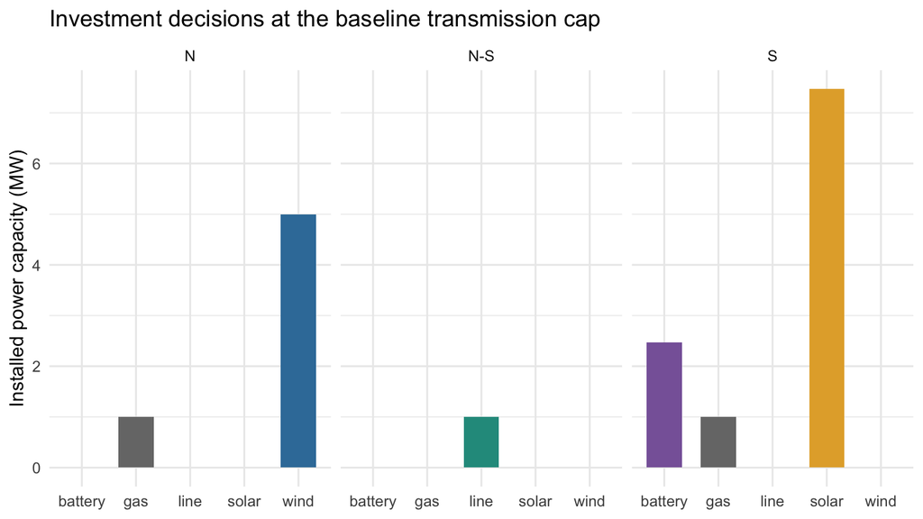

```r
plot_capacity <- ggplot(installed, aes(technology, value, fill = technology)) +
  geom_col(width = 0.65) + facet_wrap(~location) +
  scale_fill_manual(values = technology_colors) +
  labs(x = NULL, y = "Installed power capacity (MW)",
       title = "Investment decisions at the baseline transmission cap") +
  guides(fill = "none")
print(plot_capacity)
```

### Recover hourly operation and signed flows

Join the numerical solution to the variable descriptions. `pivot_wider()` puts each flow direction into a column so we can compute $f_t^{NS}-f_t^{SN}$. A positive net flow means North exports; a negative value means South exports.

```r
# Generator output and battery operations, with charging below zero.
generation <- generation_variables |>
  left_join(solution |> select(variable, value), by = "variable")
battery <- storage_variables |>
  left_join(solution |> select(variable, value), by = "variable")
flows <- flow_variables |>
  left_join(solution |> select(variable, value), by = "variable") |>
  select(period, direction, value) |>
  pivot_wider(names_from = direction, values_from = value) |>
  mutate(net_NS = NS - SN)  # Positive means North -> South
```

The baseline line carries solar electricity from South to North in period 1 and wind electricity from North to South in period 2. Its capacity is used in both directions at different times.

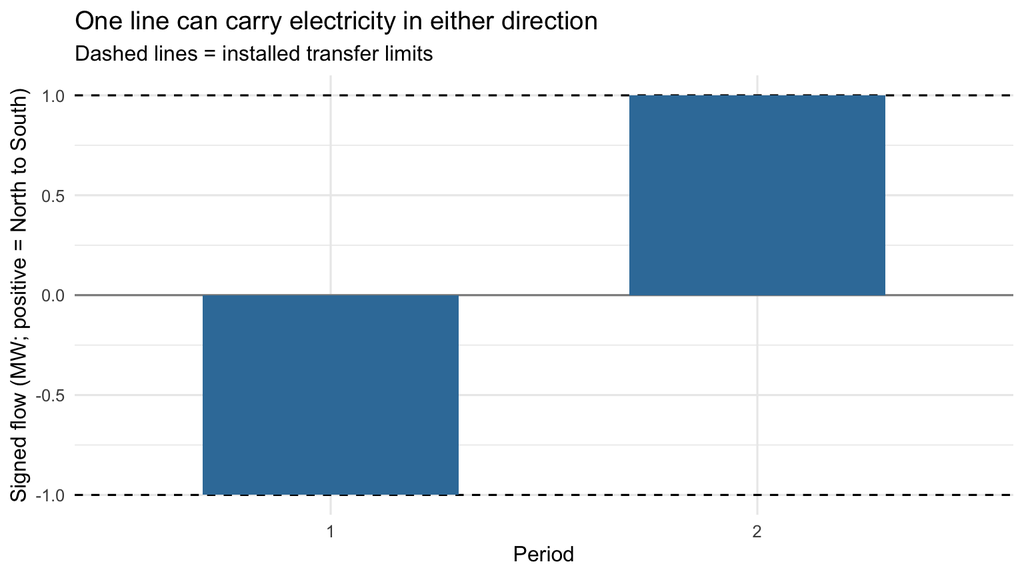

```r
# The direction can reverse: the same line shares solar in period 1 and
# wind in period 2. The dashed bounds show the installed line capacity.
line_capacity <- installed |> filter(variable == "F") |> pull(value)
plot_flow <- ggplot(flows, aes(factor(period), net_NS)) +
  geom_hline(yintercept = 0, color = "grey55") +
  geom_hline(yintercept = c(-line_capacity, line_capacity), linetype = "dashed") +
  geom_col(width = 0.6, fill = "#397CA8") +
  labs(x = "Period", y = "Signed flow (MW; positive = North to South)",
       title = "One line can carry electricity in either direction",
       subtitle = "Dashed lines = installed transfer limits")
print(plot_flow)
```

### Electricity accounting in each location

To visualize the balance, put generation, discharge, and imports above zero. Put charging and exports below zero. The positive stack minus the magnitude of the negative stack equals demand, shown by the black diamond.

In period 1, South produces extra solar electricity to serve its own demand, export, and charge its battery. In period 2, South combines imports, gas, and battery discharge. Explain each bar using the corresponding balance row.

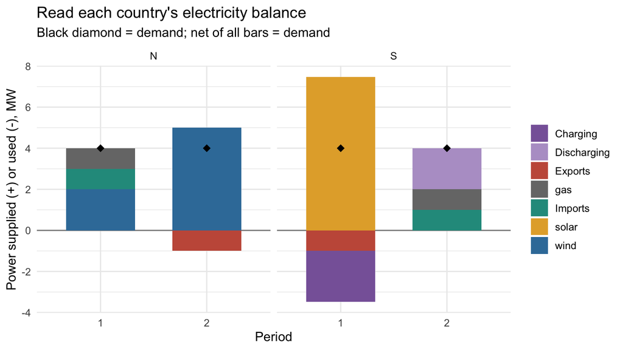

```r
trade <- bind_rows(
  flows |> transmute(location = "N", period, value = -net_NS),
  flows |> transmute(location = "S", period, value = net_NS)
) |> mutate(component = if_else(value >= 0, "Imports", "Exports"))

balance_plot_data <- bind_rows(
  generation |> transmute(location, period, component = technology, value),
  battery |> filter(operation != "soc") |>
    transmute(location, period,
              component = if_else(operation == "charge", "Charging", "Discharging"),
              value = if_else(operation == "charge", -value, value)),
  trade |> select(location, period, component, value)
)

# Bars above zero are supplies; bars below zero are charging and exports.
# Positive stack minus negative stack magnitude must equal the demand marker.
plot_balance <- ggplot(balance_plot_data,
                       aes(factor(period), value, fill = component)) +
  geom_hline(yintercept = 0, color = "grey55") +
  geom_col(width = 0.65) +
  geom_point(data = demand, aes(factor(period), demand_MW),
             inherit.aes = FALSE, shape = 18, size = 3) +
  facet_wrap(~location) +
  scale_fill_manual(values = c(technology_colors, Charging = "#8865A8",
                               Discharging = "#B6A0CD", Imports = "#26998C",
                               Exports = "#C65A48")) +
  labs(x = "Period", y = "Power supplied (+) or used (-), MW", fill = NULL,
       title = "Read each country's electricity balance",
       subtitle = "Black diamond = demand; net of all bars = demand")
print(plot_balance)
```

### Available generation versus used generation

For renewables, curtailment is

$$\text{curtailment}_{n,s,t}=\bar g_{n,s,t}G_{n,s}-g_{n,s,t}\ge0.$$

The baseline happens to use all available renewable output. The chart still separates availability from use and will reveal curtailment if changed inputs make it optimal. Zero curtailment in this solution does not mean the model requires all available generation to be used.

```r
# Actual output can be below availability: this difference is curtailment.
renewable_output <- generation |> filter(technology != "gas") |>
  left_join(installed |> select(capacity = variable, G = value), by = "capacity") |>
  mutate(available = g_bar * G, curtailed = available - value)
renewable_output |> select(location, period, available, value, curtailed)
```

```
# A tibble: 4 × 5
  location period available value curtailed
  <chr>     <dbl>     <dbl> <dbl>     <dbl>
1 N             1      2     2    -4.44e-16
2 N             2      5     5    -8.88e-16
3 S             1      7.47  7.47  0
4 S             2      0     0     0
```

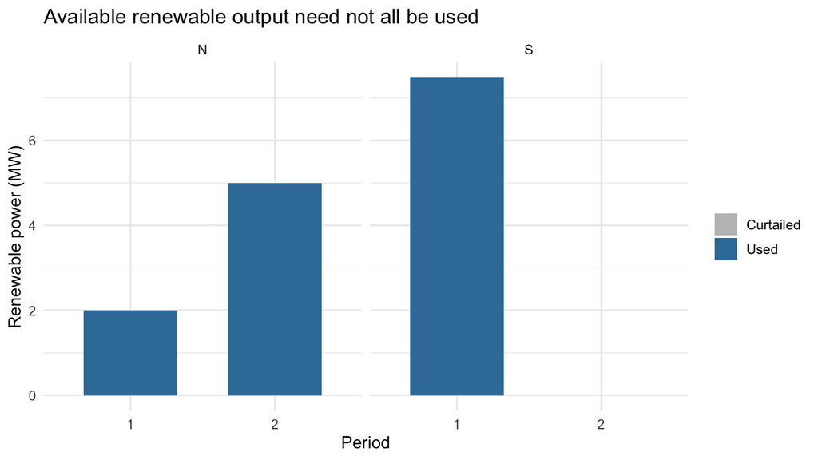

```r
plot_curtailment <- renewable_output |>
  select(location, period, Used = value, Curtailed = curtailed) |>
  pivot_longer(c(Used, Curtailed), names_to = "component", values_to = "MW") |>
  ggplot(aes(factor(period), MW, fill = component)) +
  geom_col(width = 0.65) + facet_wrap(~location) +
  scale_fill_manual(values = c(Used = "#397CA8", Curtailed = "grey75")) +
  labs(x = "Period", y = "Renewable power (MW)", fill = NULL,
       title = "Available renewable output need not all be used")
print(plot_curtailment)
```

### The path of stored energy

Add time zero to the plot using the cyclic condition. The dashed line is $E=h_{\max}G$. Notice that South’s peak stock is below this line: its charging power requirement, rather than its stock limit, determines baseline battery size. The lines connect end-of-period observations; they are not a simulation of within-hour operation.

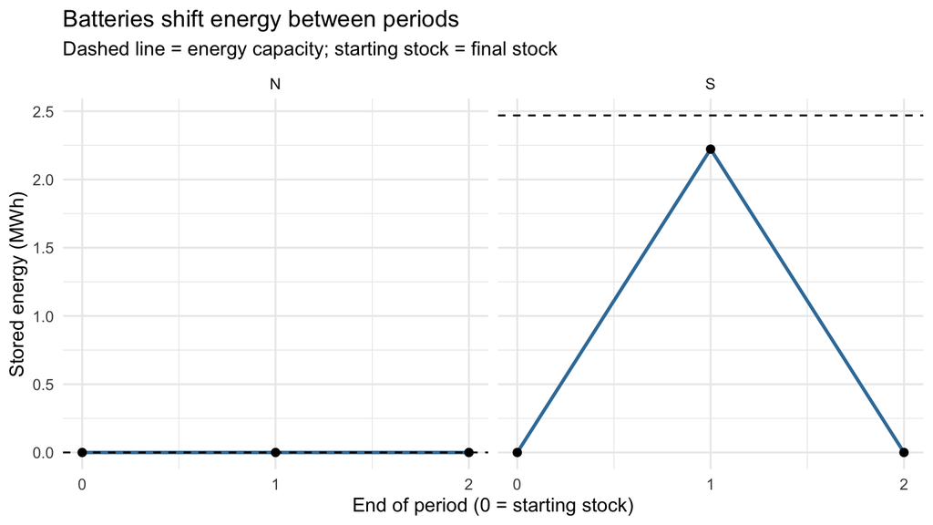

```r
# Include time zero explicitly so students can see the cyclic boundary.
stocks <- battery |> filter(operation == "soc") |>
  select(location, period, soc = value)
stocks <- bind_rows(stocks, stocks |> filter(period == 2) |> mutate(period = 0)) |>
  arrange(location, period)
energy_capacity <- installed |> filter(technology == "battery") |>
  transmute(location, E = h_max * value)

plot_storage <- ggplot(stocks, aes(period, soc)) +
  geom_line(color = "#397CA8", linewidth = 1) + geom_point(size = 2) +
  geom_hline(data = energy_capacity, aes(yintercept = E), linetype = "dashed") +
  facet_wrap(~location) + scale_x_continuous(breaks = 0:2) +
  labs(x = "End of period (0 = starting stock)", y = "Stored energy (MWh)",
       title = "Batteries shift energy between periods",
       subtitle = "Dashed line = energy capacity; starting stock = final stock")
print(plot_storage)
```

### Check energy conservation over the horizon

Adding the two locations’ balances cancels transmission. Summing over both hours and using the cyclic stocks gives

$$\text{total generation}-\text{total demand}
=\text{total charging}-\text{total discharging}
=\text{storage losses}.$$

All terms here are MWh because the periods each last one hour. This is an independent check that the sign conventions and efficiencies are consistent.

```r
# Storage must use more electricity in charging than it returns in discharge.
# This independent energy accounting also checks that imports cancel globally.
energy_totals <- battery |> filter(operation != "soc") |>
  group_by(operation) |> summarise(MWh = sum(value), .groups = "drop")
energy_totals
```

```
# A tibble: 2 × 2
  operation   MWh
  <chr>     <dbl>
1 charge     2.47
2 discharge  2
```

```r
storage_loss <- sum(battery$value[battery$operation == "charge"]) -
  sum(battery$value[battery$operation == "discharge"])
stopifnot(abs(sum(generation$value) - sum(demand$demand_MW) - storage_loss) < 1e-7)
```

## 6. Sensitivity analysis: how valuable is more transmission?

Change only $\mathrm{CAP}_{LV}$ in $lF\le\mathrm{CAP}_{LV}$, holding costs, weather, demand, and the carbon budget fixed. **Re-optimize every investment and dispatch decision at each cap.** Holding the generation portfolio fixed would answer a different question.

The loop below visibly copies `rhs`, replaces one entry, calls the same solver, and records the objective, dual, and decisions. `A` and `objective` do not change. Predict the sign of the cost change before running it.

```r
# 6. Change ONE right-hand side: the transmission-volume cap ---------------
# Stop first: predict the sign of the cost change. What can the model rebuild?
# Every capacity and dispatch variable is re-optimized, just as in the paper.
# A visible loop replaces a custom solve_model() function.
cap_grid <- seq(0, 3, by = 0.05)
scenario_rows <- list()
scenario_choices <- list()

for (i in seq_along(cap_grid)) {
  scenario_rhs <- rhs
  scenario_rhs["line_volume"] <- cap_grid[i]

  scenario_fit <- lp(direction = "min", objective.in = objective,
                     const.mat = A, const.dir = constraint_direction,
                     const.rhs = scenario_rhs, compute.sens = TRUE)
  stopifnot(scenario_fit$status == 0)

  # Check feasibility using the SAME A and the new right-hand side.
  scenario_gap <- scenario_rhs - drop(A %*% scenario_fit$solution)
  stopifnot(all(abs(scenario_gap[constraint_direction == "="]) < 1e-7),
            all(scenario_gap[constraint_direction == "<="] >= -1e-7))

  scenario_rows[[i]] <- tibble(
    CAP_LV = cap_grid[i], total_cost = scenario_fit$objval,
    mu_LV = -scenario_fit$duals[match("line_volume", row_names)]
  )
  scenario_choices[[i]] <- tibble(CAP_LV = cap_grid[i],
                                 variable = variables$variable,
                                 value = scenario_fit$solution)
}
scenarios <- bind_rows(scenario_rows)
choices <- bind_rows(scenario_choices)
scenarios |> filter(CAP_LV %in% c(0, 1, 2, 3))
```

```
# A tibble: 4 × 3
  CAP_LV total_cost mu_LV
   <dbl>      <dbl> <dbl>
1      0       22.6 1.24
2      1       21.6 0.944
3      2       20.9 0
4      3       20.9 0
```

```r
# A relaxed UPPER bound cannot increase minimum cost: the old plan is feasible.
stopifnot(all(diff(scenarios$total_cost) <= 1e-7))
```

### The cost curve

A larger upper bound expands the feasible set. The old solution remains available, so minimized cost cannot increase. The displayed curve connects solves on a 0.05-unit grid; an exact corner can lie between sampled points. For this LP, the underlying value function is piecewise linear and convex.

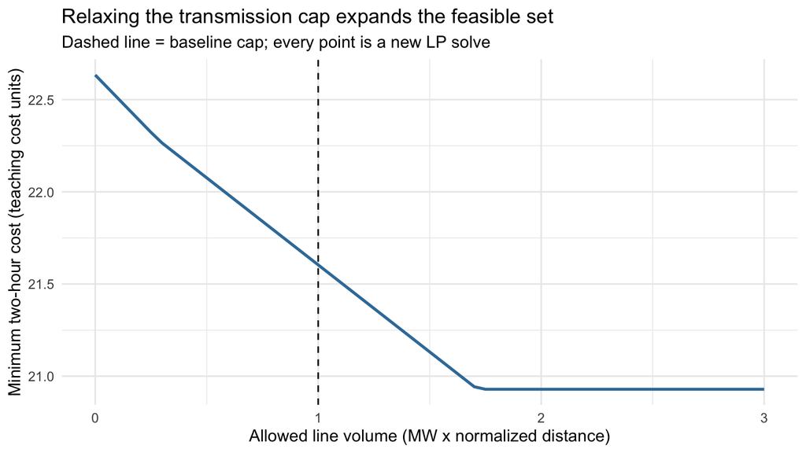

```r
plot_cost <- ggplot(scenarios, aes(CAP_LV, total_cost)) +
  geom_line(color = "#397CA8", linewidth = 1) +
  geom_vline(xintercept = CAP_LV, linetype = "dashed") +
  labs(x = "Allowed line volume (MW x normalized distance)",
       y = "Minimum two-hour cost (teaching cost units)",
       title = "Relaxing the transmission cap expands the feasible set",
       subtitle = "Dashed line = baseline cap; every point is a new LP solve")
print(plot_cost)
```

### Explain the curve with investment changes

More transmission permits a shift in the generation portfolio and reduces battery investment. Gas generation can also relocate while the common emissions budget stays fixed. Individual decisions need not be monotone, and alternative optimal plans can tie.

Once the allowance exceeds the preferred line size, the model does not build extra capacity just because it is permitted. This is why both investments and total cost eventually stop changing.

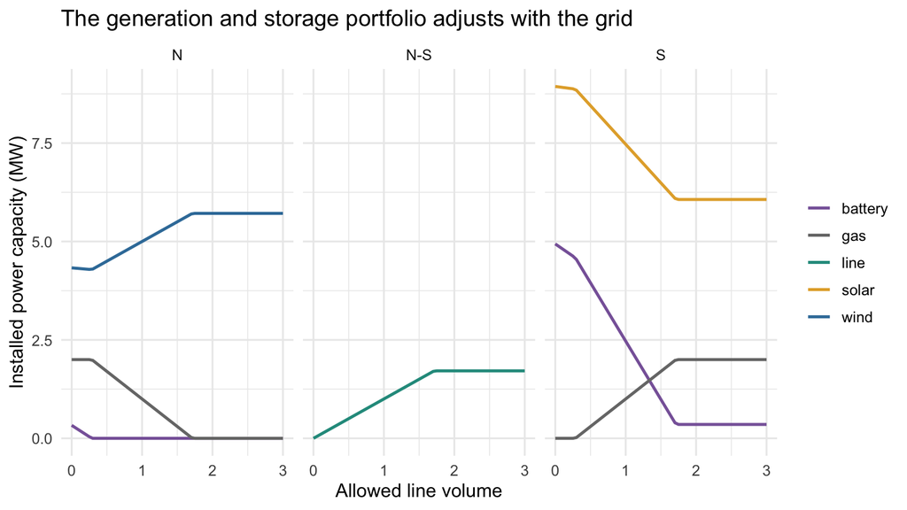

```r
capacity_path <- choices |>
  inner_join(capacity_variables |> select(variable, location, technology), by = "variable")
plot_investment <- ggplot(capacity_path, aes(CAP_LV, value, color = technology)) +
  geom_line(linewidth = 0.9) + facet_wrap(~location) +
  scale_color_manual(values = technology_colors) +
  labs(x = "Allowed line volume", y = "Installed power capacity (MW)", color = NULL,
       title = "The generation and storage portfolio adjusts with the grid")
print(plot_investment)
```

### The marginal saving

For a differentiable part of the cost curve,

$$\Delta C^*\approx-\mu_{LV}\,\Delta\mathrm{CAP}_{LV}.$$

The value is net of the line’s construction cost, which is already in the objective. When the cap is slack, complementary slackness implies

$$\mu_{LV}(\mathrm{CAP}_{LV}-lF)=0,
\qquad \mu_{LV}=0\ \text{if }\mathrm{CAP}_{LV}>lF.$$

At a corner the marginal value can depend on the direction of change, and optimal dual values need not be unique.

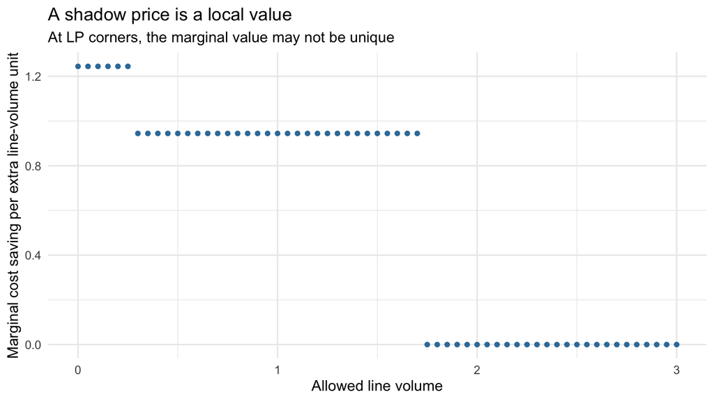

```r
plot_shadow <- ggplot(scenarios, aes(CAP_LV, mu_LV)) +
  geom_point(size = 1.4, color = "#397CA8") +
  labs(x = "Allowed line volume", y = "Marginal cost saving per extra line-volume unit",
       title = "A shadow price is a local value",
       subtitle = "At LP corners, the marginal value may not be unique")
print(plot_shadow)
```

## 7. Verify the shadow price by changing the cap a little

Choose 0.55, which is away from a corner for the supplied inputs. Solve at that cap and again after adding $\varepsilon=0.0001$. Compare

$$\mu_{LV}\quad\text{with}\quad
\frac{C^*(0.55)-C^*(0.55+\varepsilon)}{\varepsilon}.$$

The two values should agree within numerical tolerance. After changing model inputs, reconsider whether this comparison point still lies away from a corner; a mismatch at a corner is not automatically a solver error.

```r
# 7. Verify one shadow price with a small, explicit re-solve ----------------
# Choose a point away from a kink after looking at plot_cost/plot_shadow.
# Keep this separate from the scenario loop so every step is visible.
check_cap <- 0.55
small_change <- 0.0001
rhs_before <- rhs
rhs_before["line_volume"] <- check_cap
fit_before <- lp("min", objective, A, constraint_direction, rhs_before,
                 compute.sens = TRUE)

rhs_after <- rhs_before
rhs_after["line_volume"] <- check_cap + small_change
fit_after <- lp("min", objective, A, constraint_direction, rhs_after)
stopifnot(fit_before$status == 0, fit_after$status == 0)

marginal_saving_from_dual <- -fit_before$duals[match("line_volume", row_names)]
marginal_saving_from_resolve <- (fit_before$objval - fit_after$objval) / small_change
shadow_check <- tibble(
  method = c("Negative of cap dual", "Small relaxation and re-solve"),
  marginal_saving = c(marginal_saving_from_dual, marginal_saving_from_resolve)
)
shadow_check
```

```
# A tibble: 2 × 2
  method                        marginal_saving
  <chr>                                   <dbl>
1 Negative of cap dual                    0.944
2 Small relaxation and re-solve           0.944
```

```r
stopifnot(abs(marginal_saving_from_dual - marginal_saving_from_resolve) < 1e-5)
```

### Distinguish total savings from marginal savings

The cost difference between two distant scenarios is a total benefit. One local shadow price cannot be extrapolated across all capacity values. Total cost savings from relaxing the cap from $\mathrm{CAP}_{LV}^{(0)}$ to $\mathrm{CAP}_{LV}^{(1)}$ is:

$$C^*(\mathrm{CAP}_{LV}^{(0)})-C^*(\mathrm{CAP}_{LV}^{(1)})
=\int_{\mathrm{CAP}_{LV}^{(0)}}^{\mathrm{CAP}_{LV}^{(1)}}\mu_{LV}(u)\,du.$$

```r
# Compare total savings with a single marginal value. They are different objects.
scenarios |> summarise(no_trade_cost = first(total_cost),
                       expanded_grid_cost = last(total_cost),
                       total_saving = first(total_cost) - last(total_cost))
```

```
# A tibble: 1 × 3
  no_trade_cost expanded_grid_cost total_saving
          <dbl>              <dbl>        <dbl>
1          22.6               20.9         1.70
```

```r
# Do NOT multiply one shadow price by a large change in the cap unless you
# have checked that the same slope remains valid throughout that interval.
```

## 8. Optional plot export

```r
# 8. Optional: save the plots you have already displayed --------------------
# Run from this Schlachtberger directory to place these alongside the script.
# Set save_plots <- FALSE to skip saving. Plot objects always remain available.
save_plots <- TRUE
if (save_plots) {
  dir.create("Schlachtberger_example_output", showWarnings = FALSE)
  ggsave("Schlachtberger_example_output/01_weather.png", plot_weather, width = 8, height = 4)
  ggsave("Schlachtberger_example_output/02_capacity.png", plot_capacity, width = 8, height = 4)
  ggsave("Schlachtberger_example_output/03_balance.png", plot_balance, width = 8, height = 5)
  ggsave("Schlachtberger_example_output/04_curtailment.png", plot_curtailment, width = 8, height = 4)
  ggsave("Schlachtberger_example_output/05_storage.png", plot_storage, width = 8, height = 4)
  ggsave("Schlachtberger_example_output/06_cost.png", plot_cost, width = 8, height = 4)
  ggsave("Schlachtberger_example_output/07_investment.png", plot_investment, width = 8, height = 4)
  ggsave("Schlachtberger_example_output/08_shadow.png", plot_shadow, width = 8, height = 4)
  ggsave("Schlachtberger_example_output/09_flow.png", plot_flow, width = 8, height = 4)
}
```

## Connection to the reading

Schlachtberger, D. P., Brown, T., Schramm, S., and Greiner, M. (2017). [The benefits of cooperation in a highly renewable European electricity network](https://arxiv.org/abs/1704.05492). *Energy* 134: 469–481.

The objective, storage accounting, and transmission-cap experiment follow the structure of the paper. The locations, horizon, technology menu, costs, emissions budget, and normalized line length are simplified teaching inputs. No published European results are being replicated here.